# Day 6 Lecture

# Notes on complex objects

- use `names()` and `str()` to look at the structure of a complex object
- most complex objects have a list-like structure
- S3 vs. S4 classes
  - `$` notation works for S3
  - Try `@` instead for S4 classes
  - For more on S4: http://adv-r.had.co.nz/OO-essentials.html

```r
library(tidyverse)
library(reshape2)
myff <- french_fries
results <- lm(potato ~ treatment, data = myff)
results
```

```
##
## Call:
## lm(formula = potato ~ treatment, data = myff)
##
## Coefficients:
## (Intercept)   treatment2   treatment3
##     6.88793      0.11379      0.08003
```

```r
summary(results)
```

```
##
## Call:
## lm(formula = potato ~ treatment, data = myff)
##
## Residuals:
##     Min      1Q  Median      3Q     Max
## -7.0017 -2.9848  0.2983  2.9121  8.0121
##
## Coefficients:
##             Estimate Std. Error t value Pr(>|t|)
## (Intercept)  6.88793    0.23565  29.230   <2e-16 ***
## treatment2   0.11379    0.33325   0.341    0.733
## treatment3   0.08003    0.33361   0.240    0.810
## ---
## Signif. codes:  0 '***' 0.001 '**' 0.01 '*' 0.05 '.' 0.1 ' ' 1
##
## Residual standard error: 3.589 on 692 degrees of freedom
##   (1 observation deleted due to missingness)
## Multiple R-squared:  0.0001777,  Adjusted R-squared:  -0.002712
## F-statistic: 0.0615 on 2 and 692 DF,  p-value: 0.9404
```

```r
# plot(results)
class(results)
```

```
## [1] "lm"
```

```r
names(results)
```

```
##  [1] "coefficients"  "residuals"     "effects"       "rank"
##  [5] "fitted.values" "assign"        "qr"            "df.residual"
##  [9] "na.action"     "contrasts"     "xlevels"       "call"
## [13] "terms"         "model"
```

```r
str(results)
```

```
## List of 14
##  $ coefficients : Named num [1:3] 6.888 0.114 0.08
##   ..- attr(*, "names")= chr [1:3] "(Intercept)" "treatment2" "treatment3"
##  $ residuals    : Named num [1:695] -3.99 7.11 4.11 3.01 -5.69 ...
##   ..- attr(*, "names")= chr [1:695] "61" "25" "62" "26" ...
##  $ effects      : Named num [1:695] -183.288 0.918 0.861 2.805 -5.895 ...
##   ..- attr(*, "names")= chr [1:695] "(Intercept)" "treatment2" "treatment3" "" ...
##  $ rank         : int 3
##  $ fitted.values: Named num [1:695] 6.89 6.89 6.89 6.89 6.89 ...
##   ..- attr(*, "names")= chr [1:695] "61" "25" "62" "26" ...
##  $ assign       : int [1:3] 0 1 1
##  $ qr           :List of 5
##   ..$ qr   : num [1:695, 1:3] -26.3629 0.0379 0.0379 0.0379 0.0379 ...
##   .. ..- attr(*, "dimnames")=List of 2
##   .. .. ..$ : chr [1:695] "61" "25" "62" "26" ...
##   .. .. ..$ : chr [1:3] "(Intercept)" "treatment2" "treatment3"
##   .. ..- attr(*, "assign")= int [1:3] 0 1 1
##   .. ..- attr(*, "contrasts")=List of 1
##   .. .. ..$ treatment: chr "contr.treatment"
##   ..$ qraux: num [1:3] 1.04 1.03 1.04
##   ..$ pivot: int [1:3] 1 2 3
##   ..$ tol  : num 1e-07
##   ..$ rank : int 3
##   ..- attr(*, "class")= chr "qr"
##  $ df.residual  : int 692
##  $ na.action    :Class 'omit'  Named int 341
##   .. ..- attr(*, "names")= chr "315"
##  $ contrasts    :List of 1
##   ..$ treatment: chr "contr.treatment"
##  $ xlevels      :List of 1
##   ..$ treatment: chr [1:3] "1" "2" "3"
##  $ call         : language lm(formula = potato ~ treatment, data = myff)
##  $ terms        :Classes 'terms', 'formula'  language potato ~ treatment
##   .. ..- attr(*, "variables")= language list(potato, treatment)
##   .. ..- attr(*, "factors")= int [1:2, 1] 0 1
##   .. .. ..- attr(*, "dimnames")=List of 2
##   .. .. .. ..$ : chr [1:2] "potato" "treatment"
##   .. .. .. ..$ : chr "treatment"
##   .. ..- attr(*, "term.labels")= chr "treatment"
##   .. ..- attr(*, "order")= int 1
```

[output cut: 11 more lines]

```
##   .. .. ..- attr(*, "factors")= int [1:2, 1] 0 1
##   .. .. .. ..- attr(*, "dimnames")=List of 2
##   .. .. .. .. ..$ : chr [1:2] "potato" "treatment"
##   .. .. .. .. ..$ : chr "treatment"
##   .. .. ..- attr(*, "term.labels")= chr "treatment"
##   .. .. ..- attr(*, "order")= int 1
##   .. .. ..- attr(*, "intercept")= int 1
##   .. .. ..- attr(*, "response")= int 1
##   .. .. ..- attr(*, ".Environment")=<environment: R_GlobalEnv>
##   .. .. ..- attr(*, "predvars")= language list(potato, treatment)
##   .. .. ..- attr(*, "dataClasses")= Named chr [1:2] "numeric" "factor"
##   .. .. .. ..- attr(*, "names")= chr [1:2] "potato" "treatment"
##   ..- attr(*, "na.action")=Class 'omit'  Named int 341
##   .. .. ..- attr(*, "names")= chr "315"
##  - attr(*, "class")= chr "lm"
```

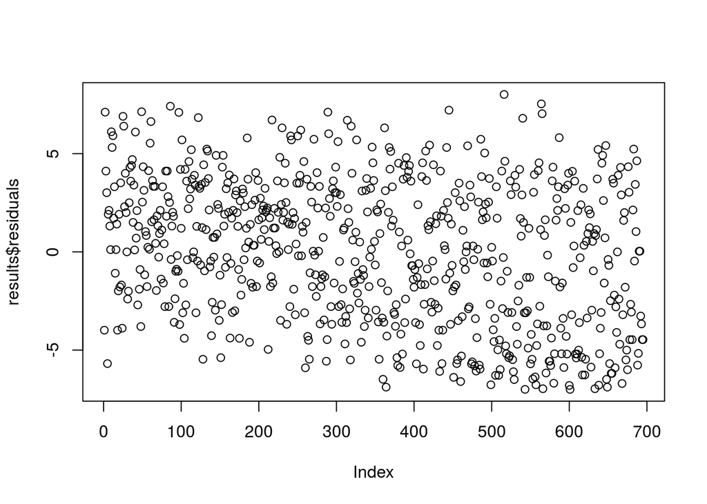

```r
plot(results$residuals)
```

```r
results.summary <- summary(results)
names(results.summary)
```

```
##  [1] "call"          "terms"         "residuals"     "coefficients"
##  [5] "aliased"       "sigma"         "df"            "r.squared"
##  [9] "adj.r.squared" "fstatistic"    "cov.unscaled"  "na.action"
```

```r
str(results.summary)
```

```
## List of 12
##  $ call         : language lm(formula = potato ~ treatment, data = myff)
##  $ terms        :Classes 'terms', 'formula'  language potato ~ treatment
##   .. ..- attr(*, "variables")= language list(potato, treatment)
##   .. ..- attr(*, "factors")= int [1:2, 1] 0 1
##   .. .. ..- attr(*, "dimnames")=List of 2
##   .. .. .. ..$ : chr [1:2] "potato" "treatment"
##   .. .. .. ..$ : chr "treatment"
##   .. ..- attr(*, "term.labels")= chr "treatment"
##   .. ..- attr(*, "order")= int 1
##   .. ..- attr(*, "intercept")= int 1
##   .. ..- attr(*, "response")= int 1
##   .. ..- attr(*, ".Environment")=<environment: R_GlobalEnv>
##   .. ..- attr(*, "predvars")= language list(potato, treatment)
##   .. ..- attr(*, "dataClasses")= Named chr [1:2] "numeric" "factor"
##   .. .. ..- attr(*, "names")= chr [1:2] "potato" "treatment"
##  $ residuals    : Named num [1:695] -3.99 7.11 4.11 3.01 -5.69 ...
##   ..- attr(*, "names")= chr [1:695] "61" "25" "62" "26" ...
##  $ coefficients : num [1:3, 1:4] 6.888 0.114 0.08 0.236 0.333 ...
##   ..- attr(*, "dimnames")=List of 2
##   .. ..$ : chr [1:3] "(Intercept)" "treatment2" "treatment3"
##   .. ..$ : chr [1:4] "Estimate" "Std. Error" "t value" "Pr(>|t|)"
##  $ aliased      : Named logi [1:3] FALSE FALSE FALSE
##   ..- attr(*, "names")= chr [1:3] "(Intercept)" "treatment2" "treatment3"
##  $ sigma        : num 3.59
##  $ df           : int [1:3] 3 692 3
##  $ r.squared    : num 0.000178
##  $ adj.r.squared: num -0.00271
##  $ fstatistic   : Named num [1:3] 0.0615 2 692
##   ..- attr(*, "names")= chr [1:3] "value" "numdf" "dendf"
##  $ cov.unscaled : num [1:3, 1:3] 0.00431 -0.00431 -0.00431 -0.00431 0.00862 ...
##   ..- attr(*, "dimnames")=List of 2
##   .. ..$ : chr [1:3] "(Intercept)" "treatment2" "treatment3"
##   .. ..$ : chr [1:3] "(Intercept)" "treatment2" "treatment3"
##  $ na.action    :Class 'omit'  Named int 341
##   .. ..- attr(*, "names")= chr "315"
##  - attr(*, "class")= chr "summary.lm"
```

```r
results.summary$adj.r.squared
```

```
## [1] -0.00271194
```

```r
results.summary$coefficients
```

```
##               Estimate Std. Error    t value      Pr(>|t|)
## (Intercept) 6.88793103  0.2356465 29.2299366 6.059799e-123
## treatment2  0.11379310  0.3332544  0.3414602  7.328609e-01
## treatment3  0.08003433  0.3336149  0.2399004  8.104785e-01
```

```r
class(results.summary$coefficients)
```

```
## [1] "matrix"
```

```r
condition.pvals <- results.summary$coefficients[c("treatment2", "treatment3"), "Pr(>|t|)"]
condition.pvals
```

```
## treatment2 treatment3
##  0.7328609  0.8104785
```

```r
# ?lm
```

The adjusted $R^2$ for this model is -0.0027119.

# Graphics overview

http://accidental-art.tumblr.com/

## The importance of graphing

```r
?anscombe
example("anscombe")
```

```
##
## anscmb> require(stats); require(graphics)
##
## anscmb> summary(anscombe)
##        x1             x2             x3             x4
##  Min.   : 4.0   Min.   : 4.0   Min.   : 4.0   Min.   : 8
##  1st Qu.: 6.5   1st Qu.: 6.5   1st Qu.: 6.5   1st Qu.: 8
##  Median : 9.0   Median : 9.0   Median : 9.0   Median : 8
##  Mean   : 9.0   Mean   : 9.0   Mean   : 9.0   Mean   : 9
##  3rd Qu.:11.5   3rd Qu.:11.5   3rd Qu.:11.5   3rd Qu.: 8
##  Max.   :14.0   Max.   :14.0   Max.   :14.0   Max.   :19
##        y1               y2              y3              y4
##  Min.   : 4.260   Min.   :3.100   Min.   : 5.39   Min.   : 5.250
##  1st Qu.: 6.315   1st Qu.:6.695   1st Qu.: 6.25   1st Qu.: 6.170
##  Median : 7.580   Median :8.140   Median : 7.11   Median : 7.040
##  Mean   : 7.501   Mean   :7.501   Mean   : 7.50   Mean   : 7.501
##  3rd Qu.: 8.570   3rd Qu.:8.950   3rd Qu.: 7.98   3rd Qu.: 8.190
##  Max.   :10.840   Max.   :9.260   Max.   :12.74   Max.   :12.500
##
## anscmb> ##-- now some "magic" to do the 4 regressions in a loop:
## anscmb> ff <- y ~ x
##
## anscmb> mods <- setNames(as.list(1:4), paste0("lm", 1:4))
##
## anscmb> for(i in 1:4) {
## anscmb+   ff[2:3] <- lapply(paste0(c("y","x"), i), as.name)
## anscmb+   ## or   ff[[2]] <- as.name(paste0("y", i))
## anscmb+   ##      ff[[3]] <- as.name(paste0("x", i))
## anscmb+   mods[[i]] <- lmi <- lm(ff, data = anscombe)
## anscmb+   print(anova(lmi))
## anscmb+ }
## Analysis of Variance Table
##
## Response: y1
##           Df Sum Sq Mean Sq F value  Pr(>F)
## x1         1 27.510 27.5100   17.99 0.00217 **
## Residuals  9 13.763  1.5292
## ---
## Signif. codes:  0 '***' 0.001 '**' 0.01 '*' 0.05 '.' 0.1 ' ' 1
## Analysis of Variance Table
```

[output cut: 46 more lines]

```
## $lm4
##              Estimate Std. Error  t value    Pr(>|t|)
## (Intercept) 3.0017273  1.1239211 2.670763 0.025590425
## x4          0.4999091  0.1178189 4.243028 0.002164602
##
##
## anscmb> ## Now, do what you should have done in the first place: PLOTS
## anscmb> op <- par(mfrow = c(2, 2), mar = 0.1+c(4,4,1,1), oma =  c(0, 0, 2, 0))
##
## anscmb> for(i in 1:4) {
## anscmb+   ff[2:3] <- lapply(paste0(c("y","x"), i), as.name)
## anscmb+   plot(ff, data = anscombe, col = "red", pch = 21, bg = "orange", cex = 1.2,
## anscmb+        xlim = c(3, 19), ylim = c(3, 13))
## anscmb+   abline(mods[[i]], col = "blue")
## anscmb+ }
```

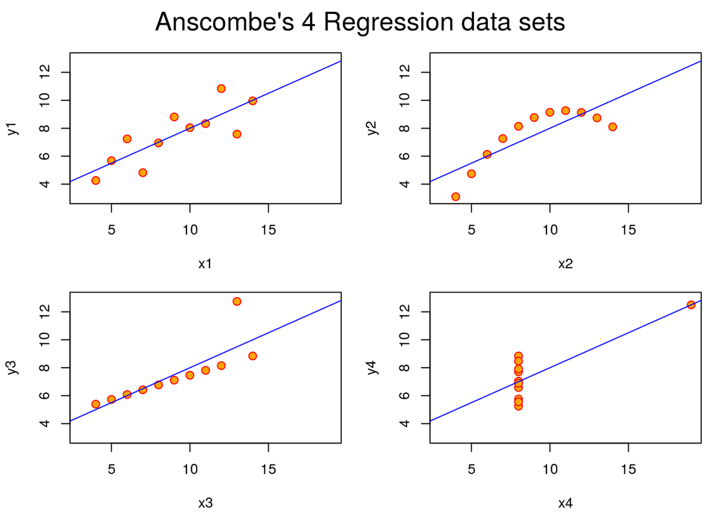

```
##
## anscmb> mtext("Anscombe's 4 Regression data sets", outer = TRUE, cex = 1.5)
##
## anscmb> par(op)
```

## Two systems

- “base” graphics
- “grid” graphics
- See *R Graphics* by Paul Murrell for a very thorough “deep-dive” into these implementations: https://www.stat.auckland.ac.nz/~paul/RG2e/

### Base graphics

- more “primitive”
- can also be much faster than grid
- lots of isolated plot functions
- lots of weird little parameters to worry about
- some handy quick-plot functions from base graphics:
  - `plot()` : a generic function that will often produce something interesting, can do scatterplots with a formula `y ~ x`
  - `hist()` : histogram of a vector
  - `boxplot()` : boxplot, using a formula `variable ~ grouping.factor`

### Grid graphics

- better for more “high-level” plots
- much more complex underlying system (IMHO)
- more powerful and extendable
- the basis of extremely popular packages such as `lattice` and `ggplot2`

## Graphics in other packages

- many packages will have some kind of graphics functions in them, for visualizing specific kinds of things
- these will often be in base graphics, “pre-canned”, etc.
- the two best more general-purpose graphics packages are `lattice` and `ggplot2`
- `ggplot2` is another Hadley Wickham project, and has the most documentation, examples, and is currently most widely used

# Using `ggplot2`

## A “Grammar of Graphics”

- based on work by Leland Wilkinson, a “theory” of graphic display of data
- Hadley implemented this framework as his dissertation
- `ggplot2` is the overhauled version of the original implementation, and it is still under active development
- the idea is to implement a general system for mapping data variables to *aesthetics* (Wilkinson’s term), i.e., visual dimensions (x, y, color, etc.)
- allows for high-level control of the structure of a plot, to allow for flexible, powerful visualizations
- the place for documentation: http://docs.ggplot2.org/current/
- another good site: http://www.cookbook-r.com/Graphs/

## Basic structure and concepts

- unlike base graphics, the *value* of `ggplot2` objects is a complex object, and `print()`-ing them renders the graph.
- the value of the object is built up by adding *layers*
- start with a call to `ggplot()` that specifies the data and some mappings of variables to aesthetics
- add “geoms” to actually render something
- add other things for fine control over graphical parameters, etc.

## Graphing the `iris` package

```r
library(ggplot2)
myris <- iris
summary(myris)
```

```
##   Sepal.Length    Sepal.Width     Petal.Length    Petal.Width
##  Min.   :4.300   Min.   :2.000   Min.   :1.000   Min.   :0.100
##  1st Qu.:5.100   1st Qu.:2.800   1st Qu.:1.600   1st Qu.:0.300
##  Median :5.800   Median :3.000   Median :4.350   Median :1.300
##  Mean   :5.843   Mean   :3.057   Mean   :3.758   Mean   :1.199
##  3rd Qu.:6.400   3rd Qu.:3.300   3rd Qu.:5.100   3rd Qu.:1.800
##  Max.   :7.900   Max.   :4.400   Max.   :6.900   Max.   :2.500
##        Species
##  setosa    :50
##  versicolor:50
##  virginica :50
##
##
##
```

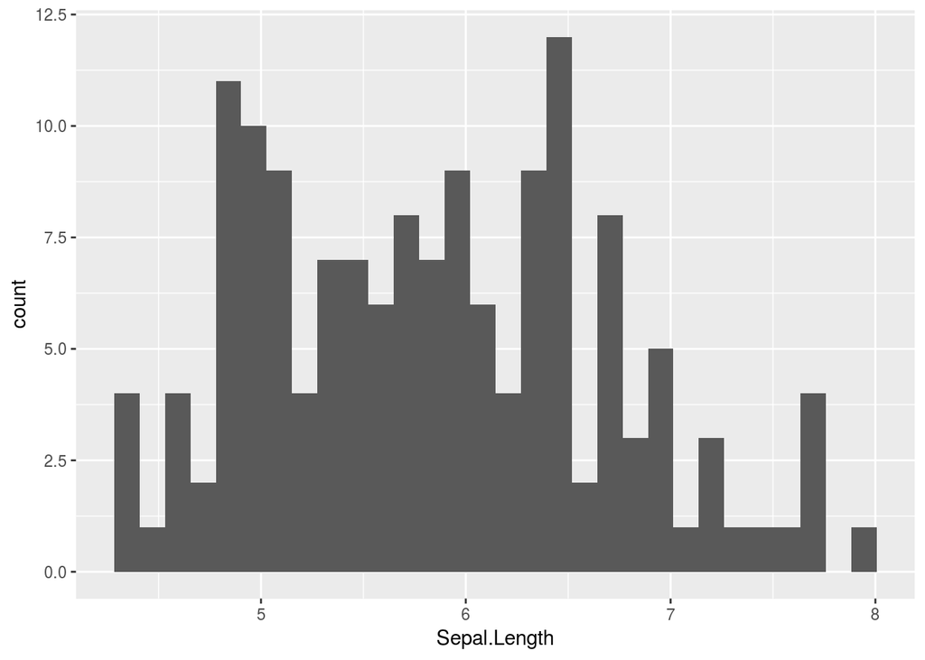

```r
ggplot(data = myris, aes(x = Sepal.Length)) + geom_histogram()
```

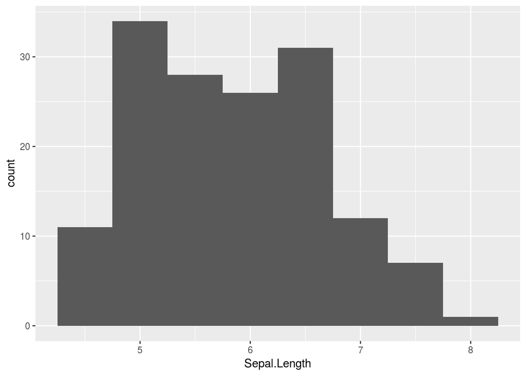

```r
ggplot(myris, aes(x = Sepal.Length)) + geom_histogram(binwidth = .5)
```

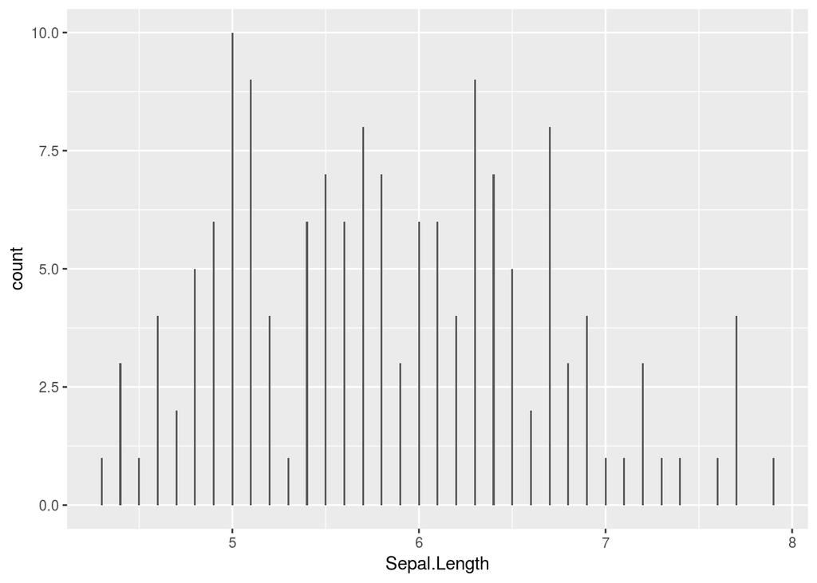

```r
ggplot(myris, aes(x = Sepal.Length)) + geom_histogram(binwidth = .01)
```

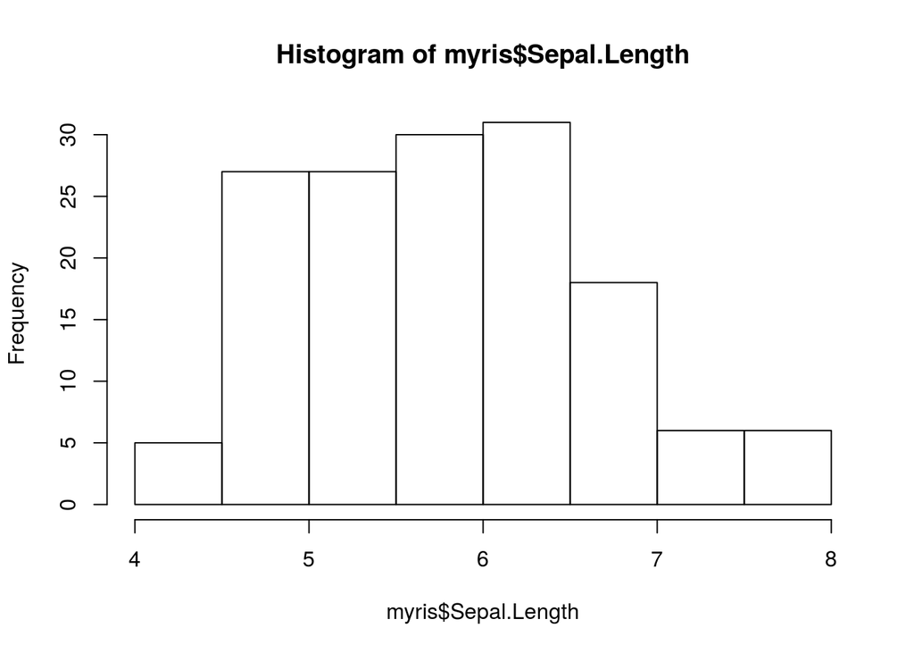

```r
hist(myris$Sepal.Length)
```

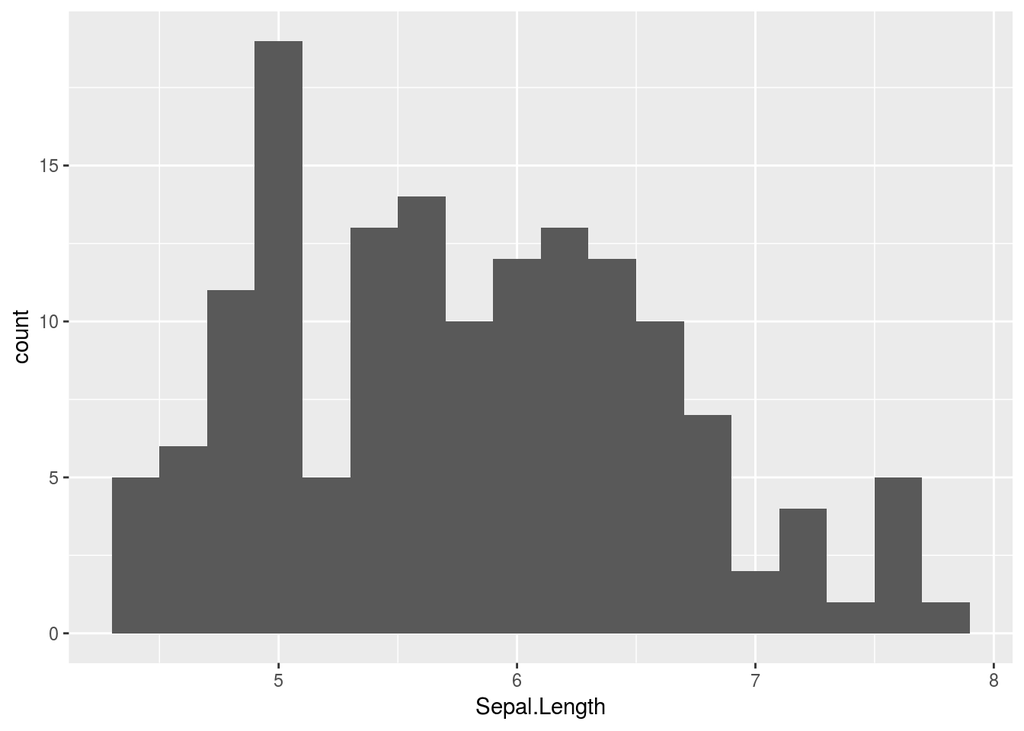

```r
mybaseplot <- ggplot(myris, aes(x = Sepal.Length))

mybaseplot + geom_histogram(binwidth = .2)
```

```r
names(mybaseplot)
```

```
## [1] "data"        "layers"      "scales"      "mapping"     "theme"
## [6] "coordinates" "facet"       "plot_env"    "labels"
```

```r
str(mybaseplot)
```

```
## List of 9
##  $ data       :'data.frame': 150 obs. of  5 variables:
##   ..$ Sepal.Length: num [1:150] 5.1 4.9 4.7 4.6 5 5.4 4.6 5 4.4 4.9 ...
##   ..$ Sepal.Width : num [1:150] 3.5 3 3.2 3.1 3.6 3.9 3.4 3.4 2.9 3.1 ...
##   ..$ Petal.Length: num [1:150] 1.4 1.4 1.3 1.5 1.4 1.7 1.4 1.5 1.4 1.5 ...
##   ..$ Petal.Width : num [1:150] 0.2 0.2 0.2 0.2 0.2 0.4 0.3 0.2 0.2 0.1 ...
##   ..$ Species     : Factor w/ 3 levels "setosa","versicolor",..: 1 1 1 1 1 1 1 1 1 1 ...
##  $ layers     : list()
##  $ scales     :Classes 'ScalesList', 'ggproto' <ggproto object: Class ScalesList>
##     add: function
##     clone: function
##     find: function
##     get_scales: function
##     has_scale: function
##     input: function
##     n: function
##     non_position_scales: function
##     scales: NULL
##     super:  <ggproto object: Class ScalesList>
##  $ mapping    :List of 1
##   ..$ x: symbol Sepal.Length
##  $ theme      : list()
##  $ coordinates:Classes 'CoordCartesian', 'Coord', 'ggproto' <ggproto object: Class CoordCartesian, Coord>
##     aspect: function
##     distance: function
##     expand: TRUE
##     is_linear: function
##     labels: function
##     limits: list
##     range: function
##     render_axis_h: function
##     render_axis_v: function
##     render_bg: function
##     render_fg: function
##     train: function
##     transform: function
##     super:  <ggproto object: Class CoordCartesian, Coord>
##  $ facet      :Classes 'FacetNull', 'Facet', 'ggproto' <ggproto object: Class FacetNull, Facet>
##     compute_layout: function
##     draw_back: function
```

[output cut: 8 more lines]

```
##     render_back: function
##     render_front: function
##     render_panels: function
##     setup_data: function
##     setup_params: function
##     shrink: TRUE
##     train: function
##     train_positions: function
##     train_scales: function
##     vars: function
##     super:  <ggproto object: Class FacetNull, Facet>
##  $ plot_env   :<environment: R_GlobalEnv>
##  $ labels     :List of 1
##   ..$ x: chr "Sepal.Length"
##  - attr(*, "class")= chr [1:2] "gg" "ggplot"
```

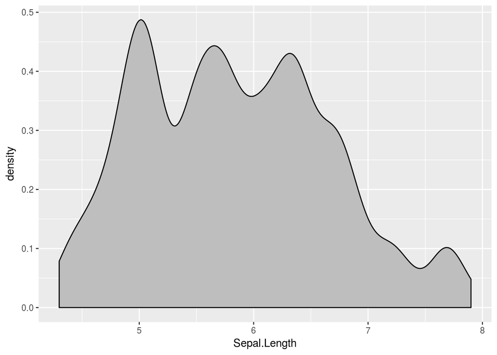

```r
base.density <- mybaseplot + geom_density(adjust = .5, fill = "grey")
base.density
```

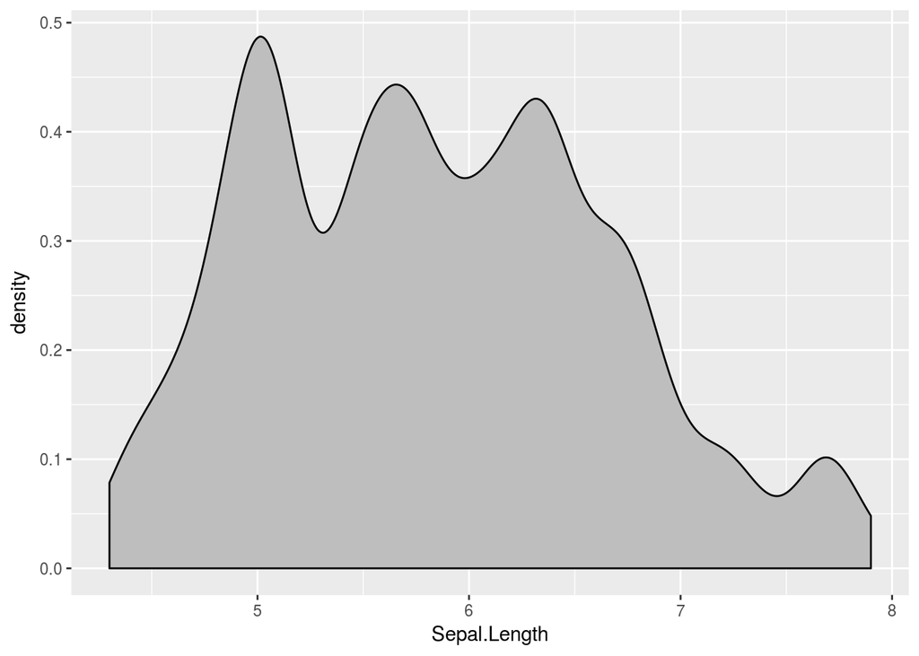

```r
mydensity <- geom_density(adjust = .5, fill = "grey")

mybaseplot + mydensity
```

```r
colors()
```

```
##   [1] "white"                "aliceblue"            "antiquewhite"
##   [4] "antiquewhite1"        "antiquewhite2"        "antiquewhite3"
##   [7] "antiquewhite4"        "aquamarine"           "aquamarine1"
##  [10] "aquamarine2"          "aquamarine3"          "aquamarine4"
##  [13] "azure"                "azure1"               "azure2"
##  [16] "azure3"               "azure4"               "beige"
##  [19] "bisque"               "bisque1"              "bisque2"
##  [22] "bisque3"              "bisque4"              "black"
##  [25] "blanchedalmond"       "blue"                 "blue1"
##  [28] "blue2"                "blue3"                "blue4"
##  [31] "blueviolet"           "brown"                "brown1"
##  [34] "brown2"               "brown3"               "brown4"
##  [37] "burlywood"            "burlywood1"           "burlywood2"
##  [40] "burlywood3"           "burlywood4"           "cadetblue"
##  [43] "cadetblue1"           "cadetblue2"           "cadetblue3"
```

[output cut: 204 more lines]

```r
?RGB
```

### Saving plots

```r
pdf("myplot.pdf", width = 10, height = 4)
ggplot(myris, aes(x = Sepal.Length)) + geom_histogram()
dev.off()
```

```r
?Devices

# look into other PDF readers if you want to be
# able to leave the file "open" (i.e., displayed)
# on your computer while you are editing/changing
# the file
```

## Some more parameters

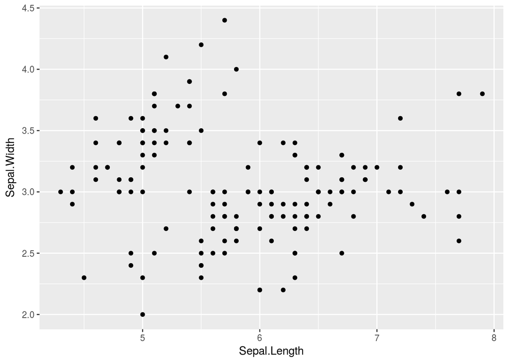

```r
# pdf("bunch of plots.pdf")
ggplot(myris, aes(x = Sepal.Length, y = Sepal.Width)) + geom_point()
```

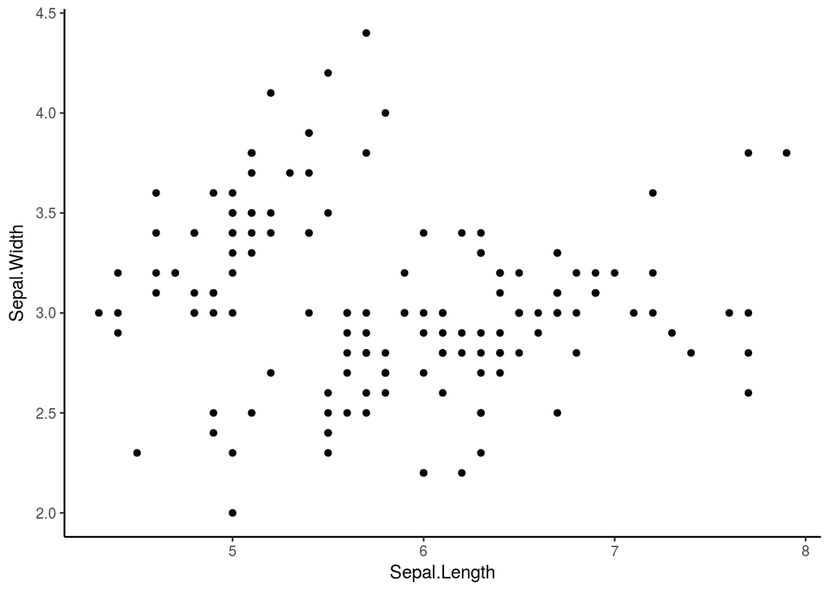

```r
ggplot(myris, aes(x = Sepal.Length, y = Sepal.Width)) + geom_point() + theme_classic()
```

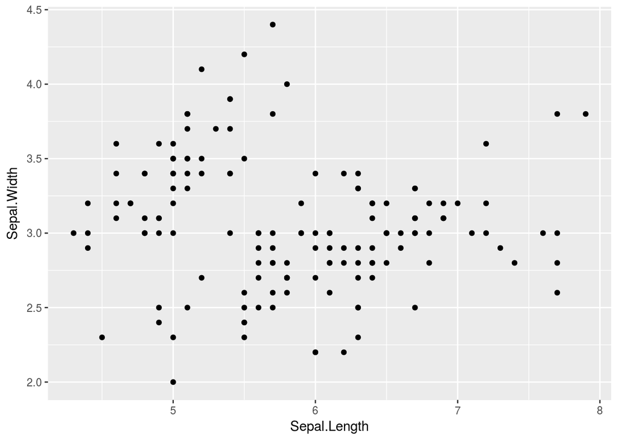

```r
myscatterplot <- ggplot(myris, aes(x = Sepal.Length, y = Sepal.Width)) + geom_point()
myscatterplot
```

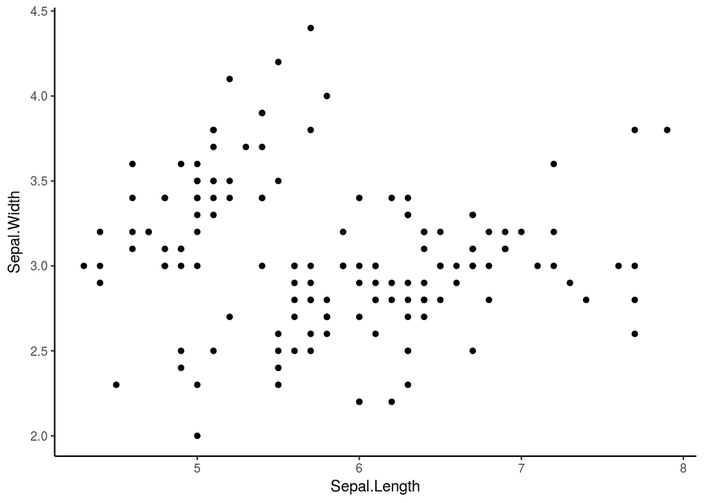

```r
myscatterplot + theme_classic()
```

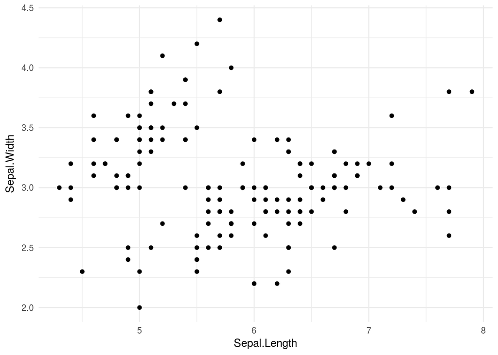

```r
myscatterplot + theme_minimal()
```

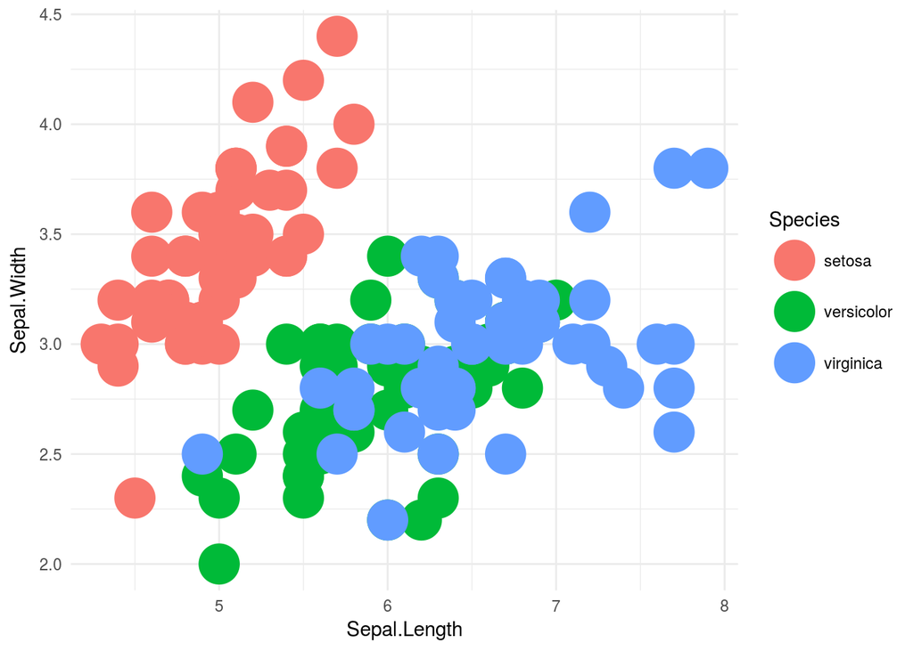

```r
ggplot(myris, aes(x = Sepal.Length, y = Sepal.Width)) +
  geom_point(aes(color = Species), size = 10) +
  theme_minimal()
```

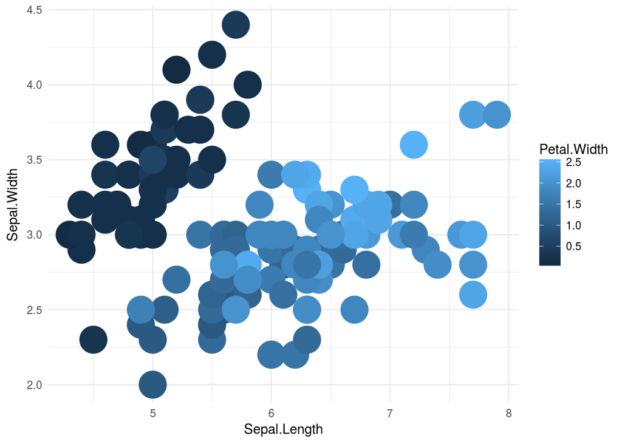

```r
ggplot(myris, aes(x = Sepal.Length, y = Sepal.Width)) +
  geom_point(aes(color = Petal.Width), size = 10) +
  theme_minimal()
```

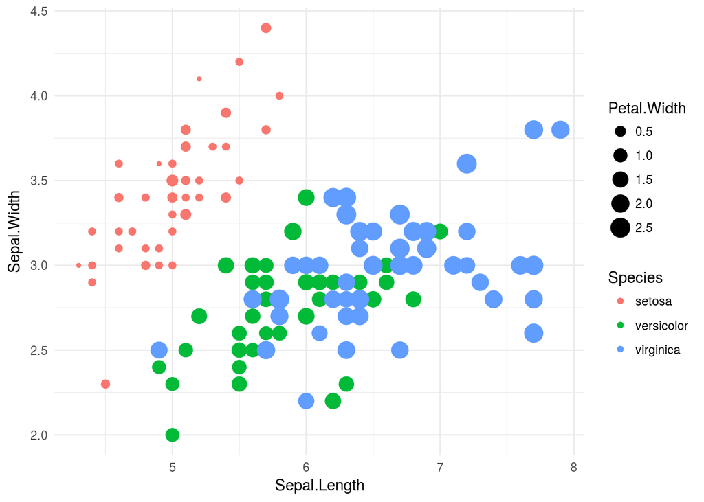

```r
ggplot(myris, aes(x = Sepal.Length, y = Sepal.Width)) +
  geom_point(aes(color = Species, size = Petal.Width)) +
  theme_minimal()
```

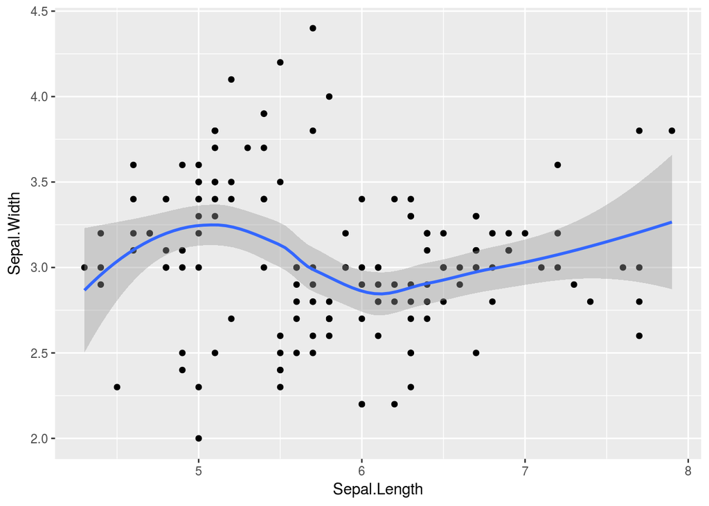

```r
ggplot(myris, aes(x = Sepal.Length, y = Sepal.Width)) +
  geom_point() +
  geom_smooth()
```

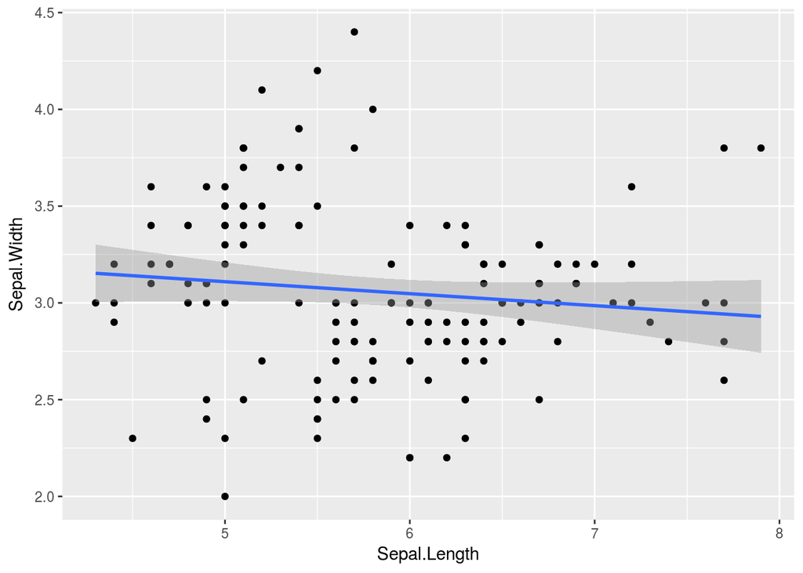

```r
ggplot(myris, aes(x = Sepal.Length, y = Sepal.Width)) +
  geom_point() +
  geom_smooth(method = "lm")
```

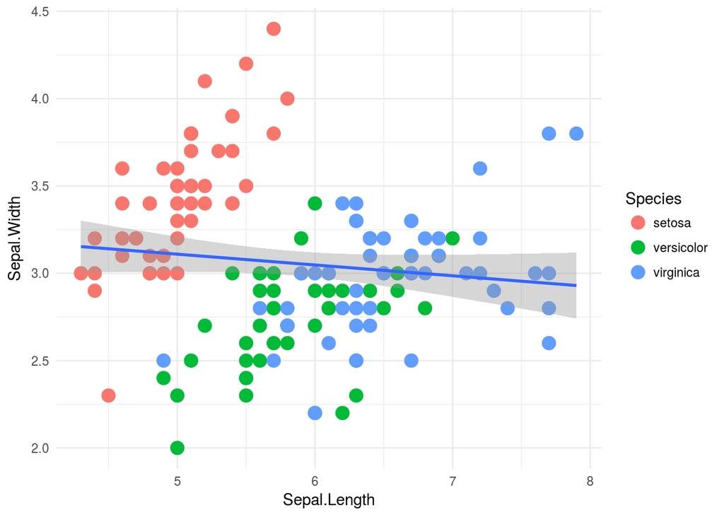

```r
ggplot(myris, aes(x = Sepal.Length, y = Sepal.Width)) +
  geom_point(aes(color = Species), size = 4) +
  theme_minimal() +
  geom_smooth(method = "lm")
```

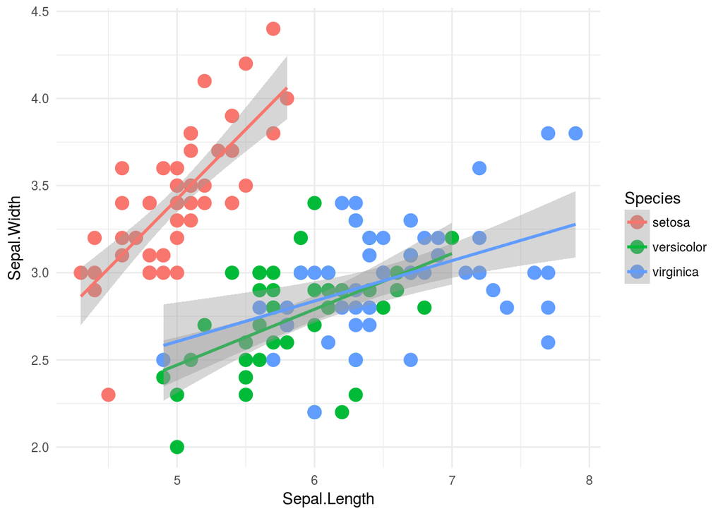

```r
ggplot(myris, aes(x = Sepal.Length, y = Sepal.Width, color = Species)) +
  geom_point(size = 4) +
  theme_minimal() +
  geom_smooth(method = "lm")
```

```r
# dev.off()
```

### More on colors

- http://colorbrewer2.org/

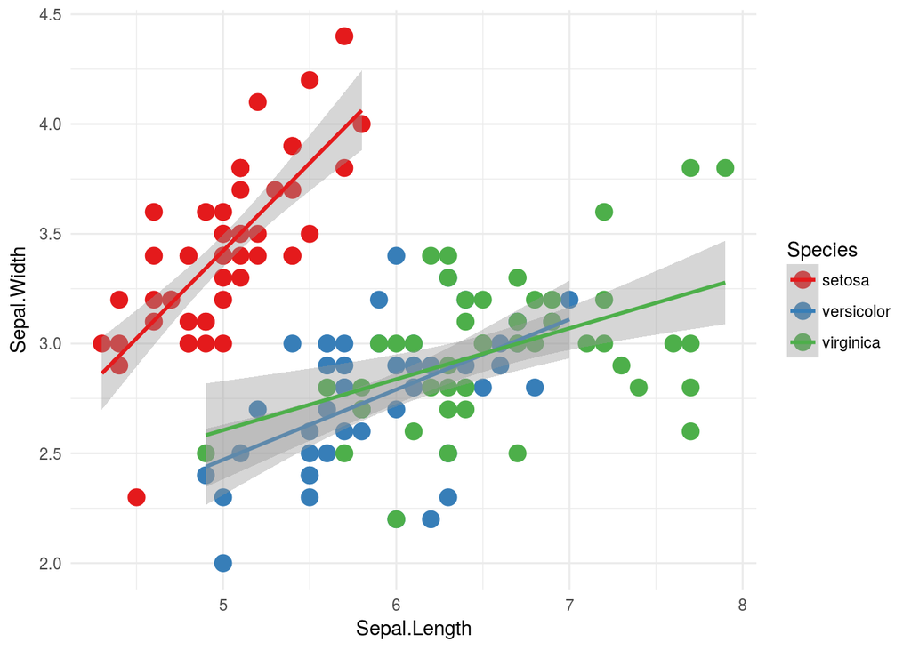

```r
ggplot(myris, aes(x = Sepal.Length, y = Sepal.Width, color = Species)) +
  geom_point(size = 4) +
  theme_minimal() +
  geom_smooth(method = "lm") +
  scale_color_brewer(palette = "Set1")
```

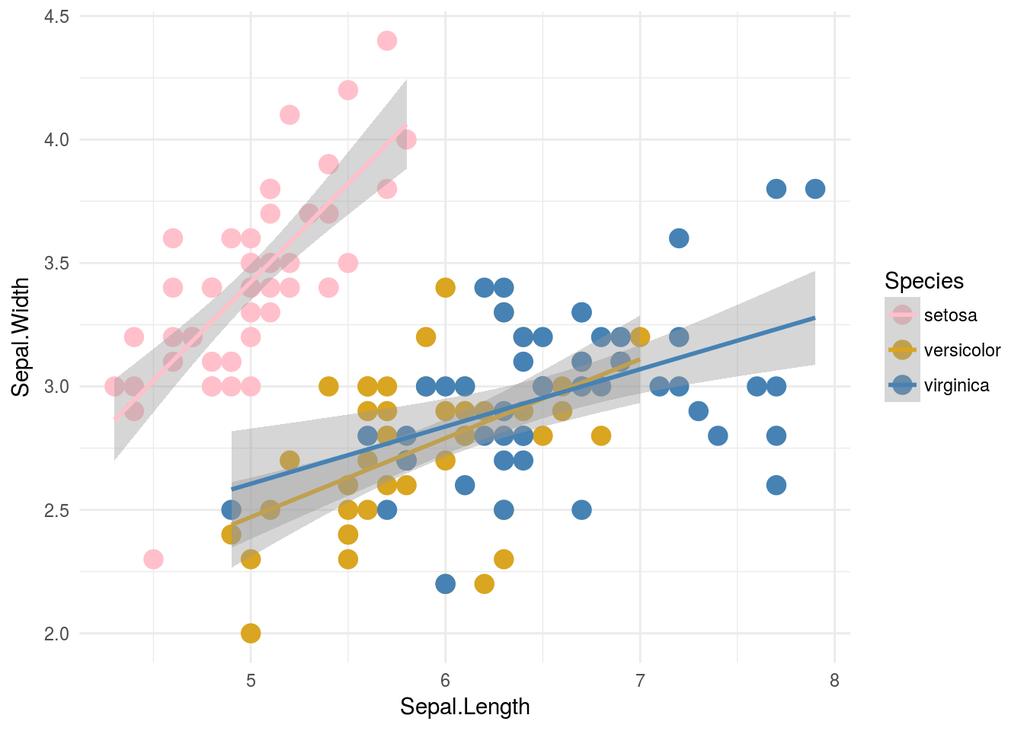

```r
ggplot(myris, aes(x = Sepal.Length, y = Sepal.Width, color = Species)) +
  geom_point(size = 4) +
  theme_minimal() +
  geom_smooth(method = "lm") +
  scale_color_manual(values = c("pink", "goldenrod", "steelblue"))
```

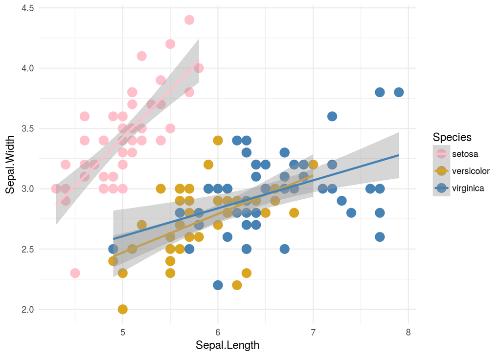

```r
my.palette <- scale_color_manual(values = c("pink", "goldenrod", "steelblue"))

ggplot(myris, aes(x = Sepal.Length, y = Sepal.Width, color = Species)) +
  geom_point(size = 4) +
  theme_minimal() +
  geom_smooth(method = "lm") +
  my.palette
```

### Facetting

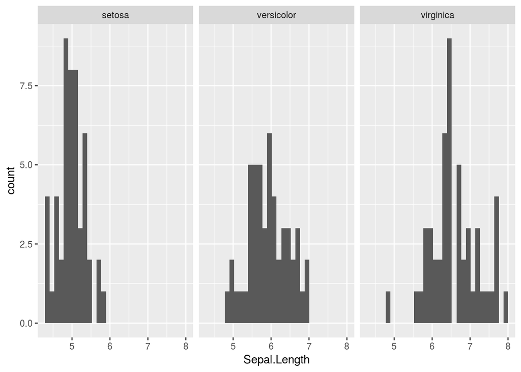

```r
ggplot(myris, aes(x = Sepal.Length)) + geom_histogram() +
  facet_wrap(~ Species)
```

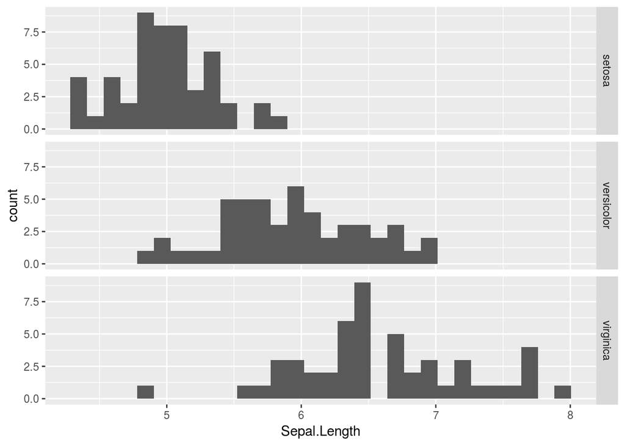

```r
ggplot(myris, aes(x = Sepal.Length)) + geom_histogram() +
  facet_grid(Species ~ .)
```

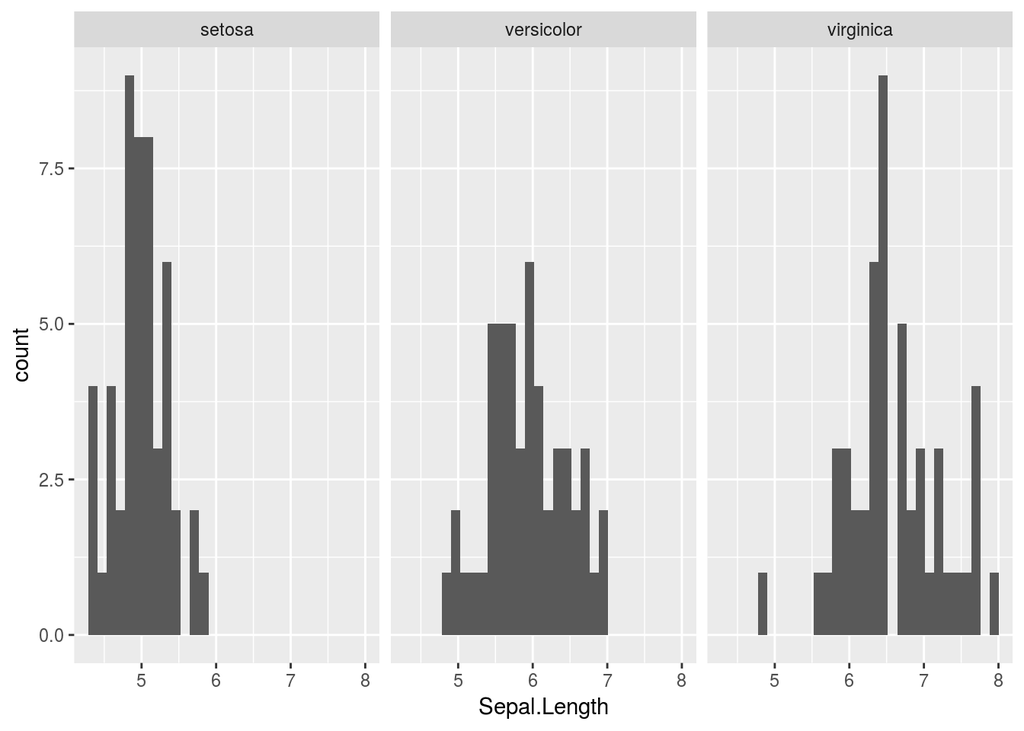

```r
ggplot(myris, aes(x = Sepal.Length)) + geom_histogram() +
  facet_grid(. ~ Species)
```

```r
myris.tidy <- gather(myris, variable, cm, Sepal.Length:Petal.Width) %>%
  separate(variable, sep = "\\.", c("part", "dimension"))
head(myris.tidy)
```

```
##   Species  part dimension  cm
## 1  setosa Sepal    Length 5.1
## 2  setosa Sepal    Length 4.9
## 3  setosa Sepal    Length 4.7
## 4  setosa Sepal    Length 4.6
## 5  setosa Sepal    Length 5.0
## 6  setosa Sepal    Length 5.4
```

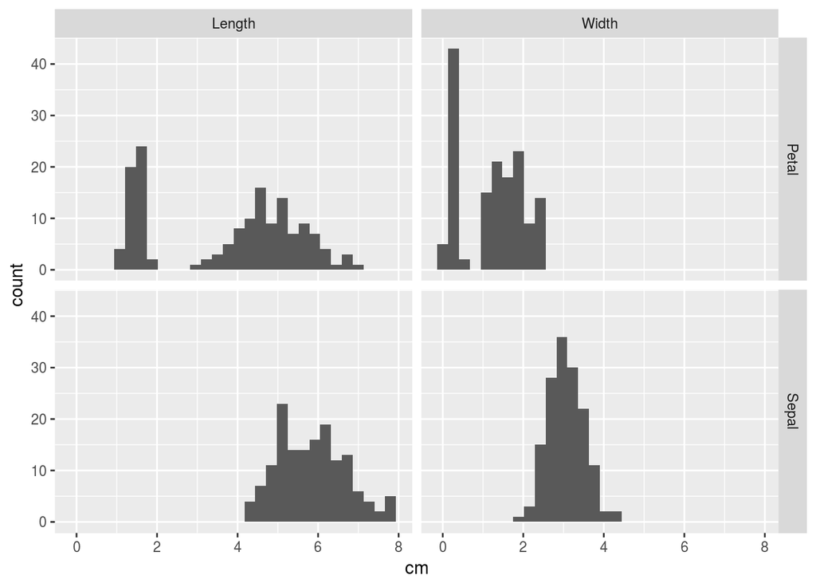

```r
ggplot(myris.tidy, aes(cm)) + geom_histogram() +
  facet_grid(part ~ dimension)
```

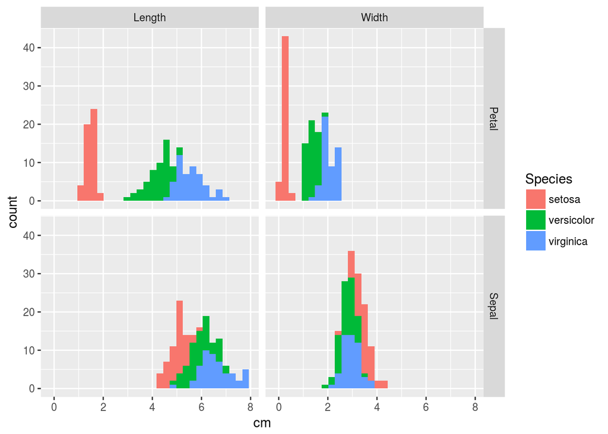

```r
ggplot(myris.tidy, aes(cm)) + geom_histogram(aes(fill = Species)) +
  facet_grid(part ~ dimension)
```

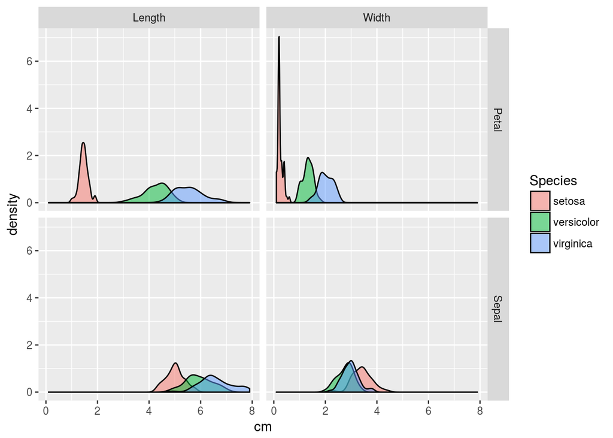

```r
ggplot(myris.tidy, aes(cm)) + geom_density(aes(fill = Species), alpha = .5) +
  facet_grid(part ~ dimension)
```

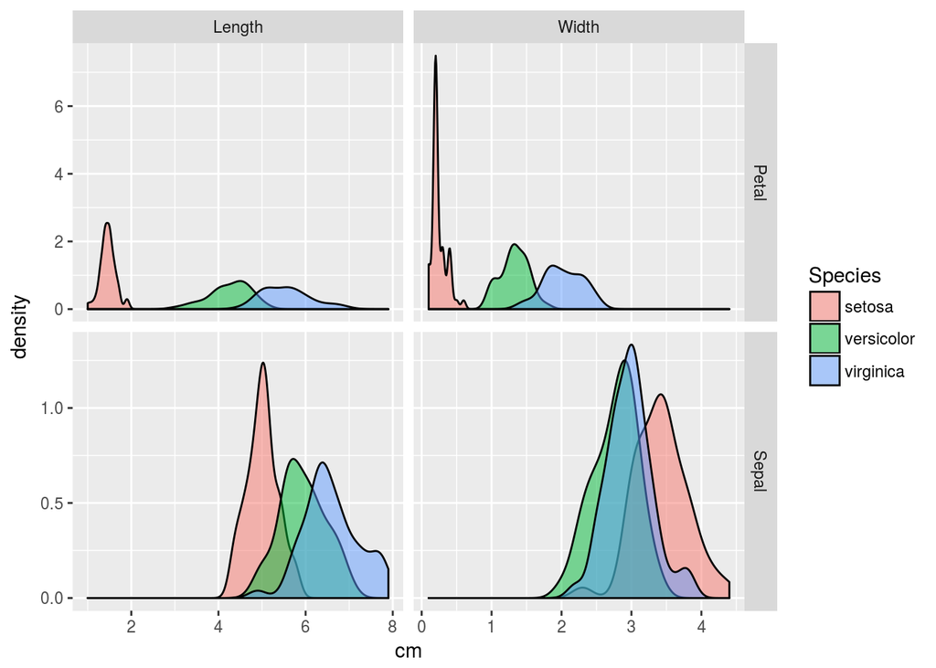

```r
ggplot(myris.tidy, aes(cm)) + geom_density(aes(fill = Species), alpha = .5) +
  facet_grid(part ~ dimension, scales = "free")
```

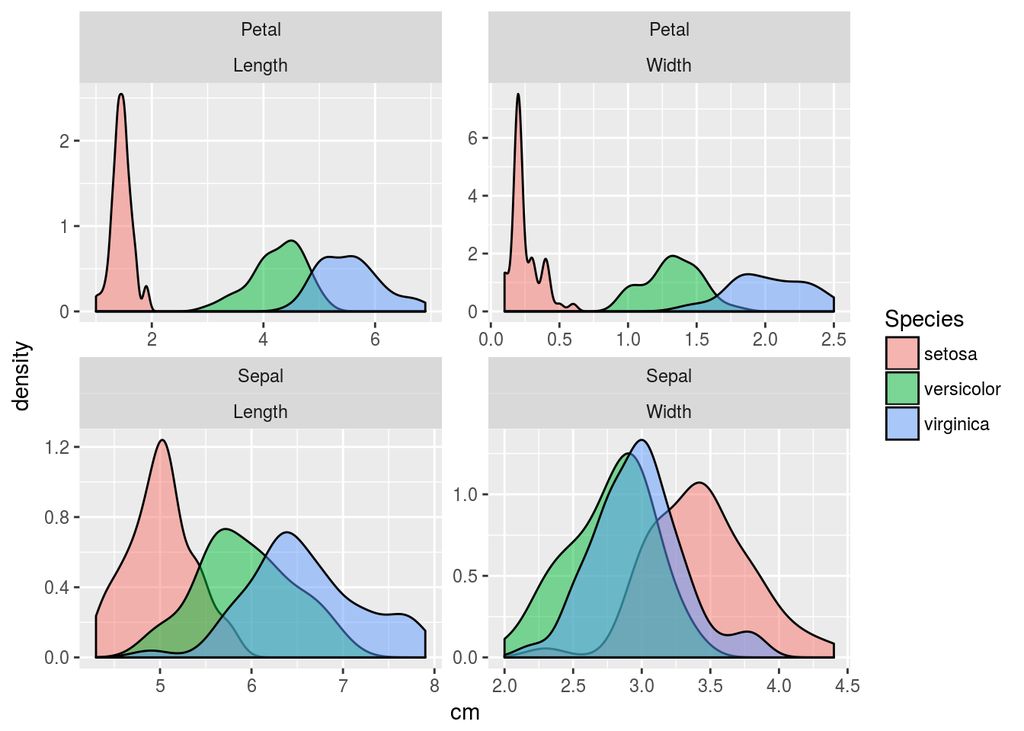

```r
ggplot(myris.tidy, aes(cm)) + geom_density(aes(fill = Species), alpha = .5) +
  facet_wrap(~ part + dimension, scales = "free")
```

# Going further

http://ggplot2.tidyverse.org/reference/